# Data visualization

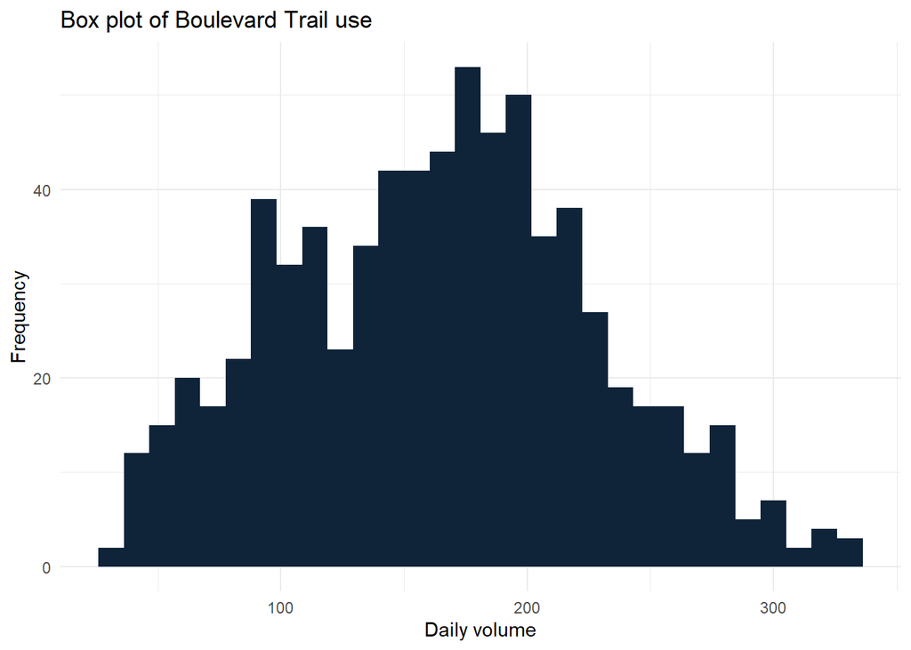

```r
# Histogram
ggplot(dat, aes(x=CountBL)) +
  geom_histogram(fill="#0F2439") +
  labs(x="Daily volume", y="Frequency",
    title="Box plot of Boulevard Trail use") +
  theme_minimal()
```

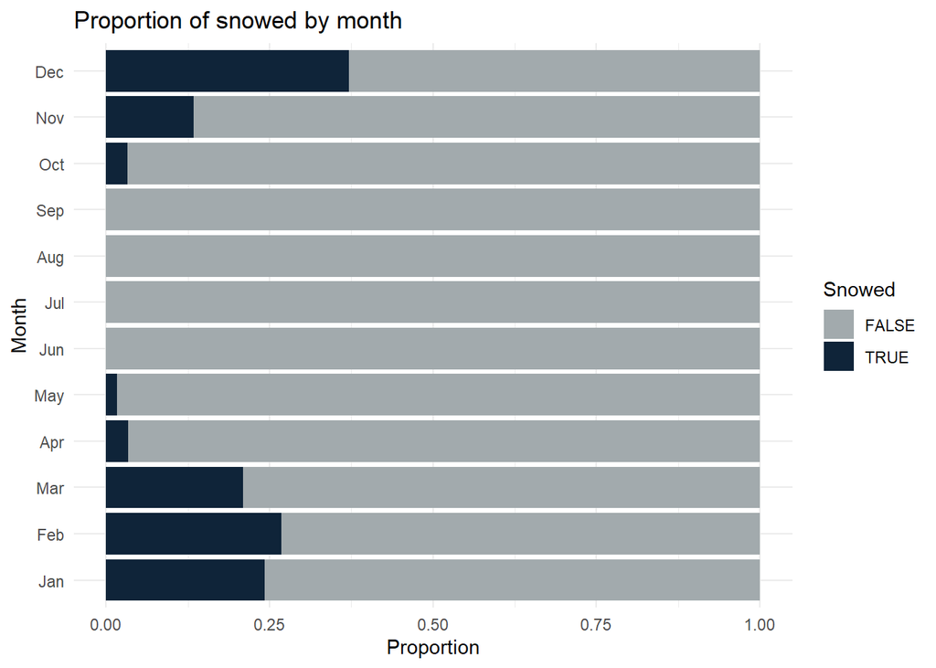

```r
# Stacked bar chart
df1 <- as.data.frame(tabp2)
names(df1) <- c("Snowed", "Month", "Proportion")
ggplot(df1, aes(x=Proportion, y=Month, fill=Snowed)) +
  geom_bar(stat="identity", position="stack") +
  scale_fill_manual(values=c("#A2AAAD", "#0F2439")) +
  labs(x="Proportion", y="Month",
       title="Proportion of snowed by month",
       fill="Snowed") +
  theme_minimal()
```

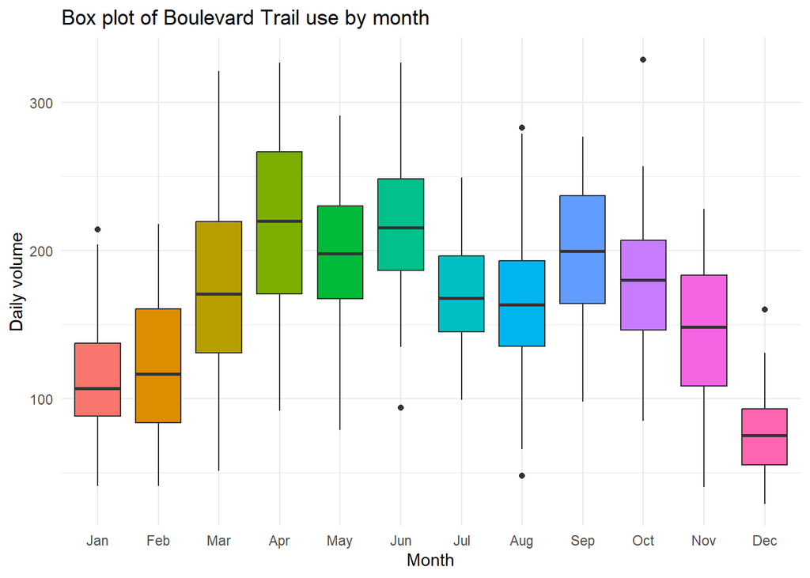

```r
rm(df1)

# Multi-group box plot
ggplot(dat, aes(x=Month, y=CountBL, fill=Month)) +
  geom_boxplot() +
  labs(x="Month", y="Daily volume",
    title="Box plot of Boulevard Trail use by month") +
  guides(fill="none") +
  theme_minimal()
```

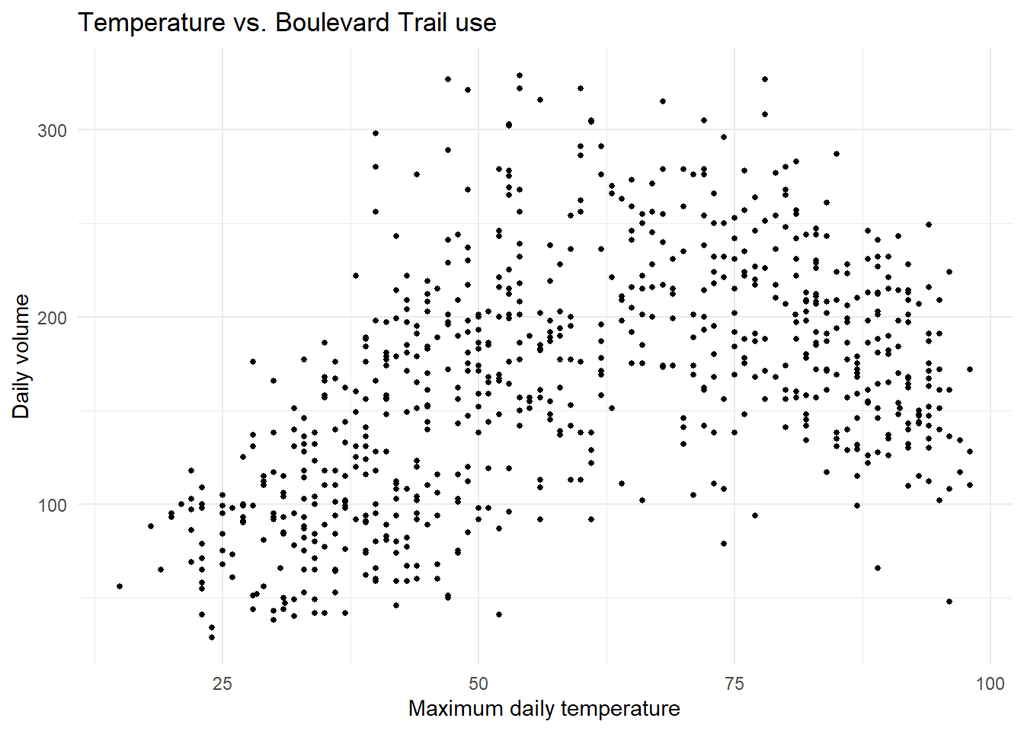

```r
# Scatter plot
ggplot(dat, aes(x=Temp_Max, y=CountBL)) +
  geom_point(size=1) +
  labs(x="Maximum daily temperature",
       y="Daily volume",
       title="Temperature vs. Boulevard Trail use") +
  theme_minimal()
```

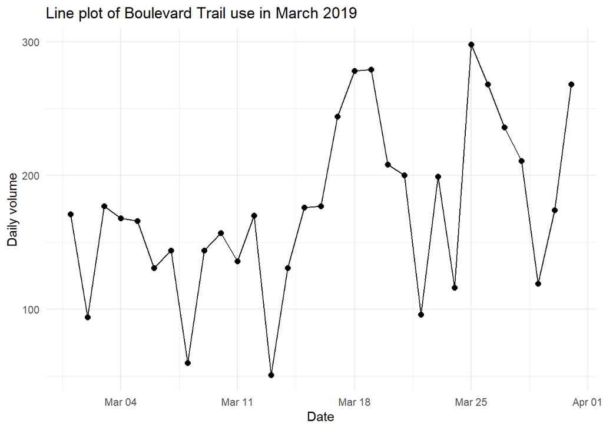

```r
# Line chart
ggplot(temp1, aes(x=Date, y=CountBL)) +
  geom_line() +
  geom_point(size=2) +
  labs(x="Date", y="Daily volume",
    title = "Line plot of Boulevard Trail use in March 2019") +
  theme_minimal()
```

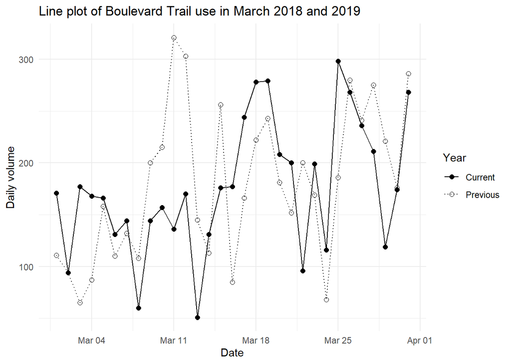

```r
# Line chart
df2 <- data.frame(Date = rep(temp$Date, 2),
  Traffic=c(temp$CountBL, temp$CountBL_2018),
  Year=rep(c("Current", "Previous"), each=nrow(temp)))
ggplot(df2, aes(x=Date, y=Traffic, color=Year, linetype=Year)) +
  geom_line() +
  geom_point(aes(shape=Year), size = 2) +
  scale_color_manual(values=c("Current"="black", "Previous"="black")) +
  scale_shape_manual(values=c("Current"=19, "Previous"=1)) +
  scale_linetype_manual(values=c("Current"="solid", "Previous"="dotted")) +
  labs(x="Date", y="Daily volume",
    title = "Line plot of Boulevard Trail use in March 2018 and 2019") +
  theme_minimal()
```

```r
rm(df2)
```

In Python, the grammar of graphics is implemented in the [**`plotnine`** package](https://plotnine.org/), based on R’s ggplot2. There is [a useful guide](https://plotnine.org/guide/install.html) on how to setup and use the functionality of `plotnine`.

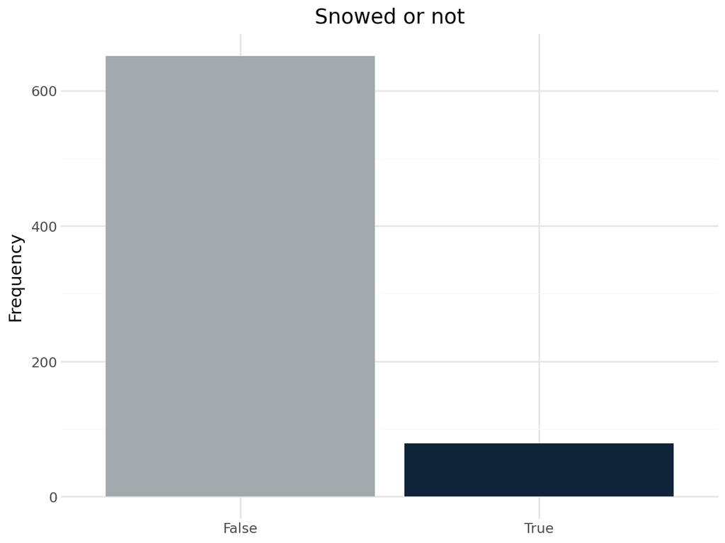

```python
# Load modules
import plotnine as p9

# Pie chart
# not possible, plotnine does not have
# coord_polar from ggplot2

# Column chart
df1 = pd.DataFrame({"Category":tabf1.index, "Frequency":tabf1})
plot = (p9.ggplot(df1, p9.aes(x="Category", y="Frequency", fill="Category")) +
  p9.geom_bar(stat="identity", show_legend=False) +
  p9.scale_fill_manual(values=["#A2AAAD", "#0F2439"]) +
  p9.labs(title="Snowed or not", x="") +
  p9.theme_minimal())
plot.show()
```

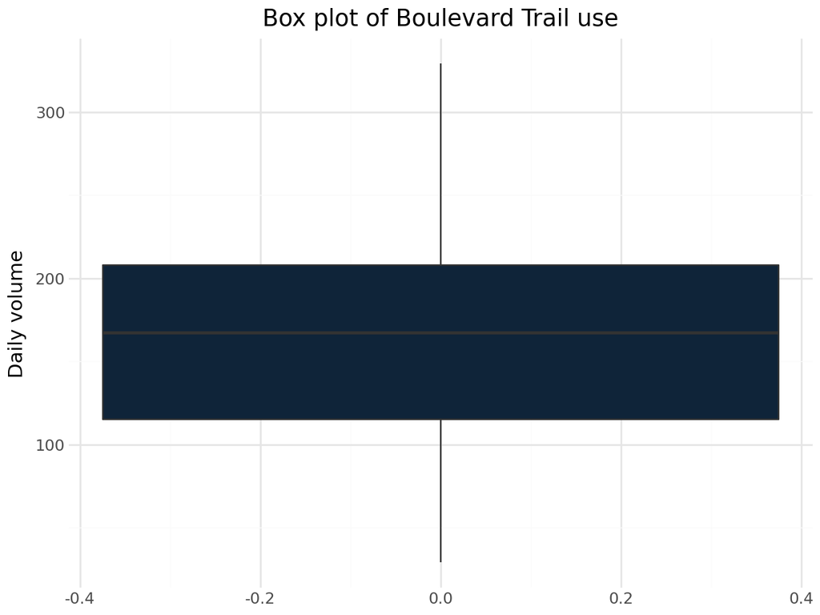

```python
del df1

# Box plot
plot = (p9.ggplot(dat, p9.aes(y="CountBL")) +
  p9.geom_boxplot(fill="#0F2439") +
  p9.labs(y="Daily volume",
    title="Box plot of Boulevard Trail use") +
  p9.theme_minimal())
plot.show()
```

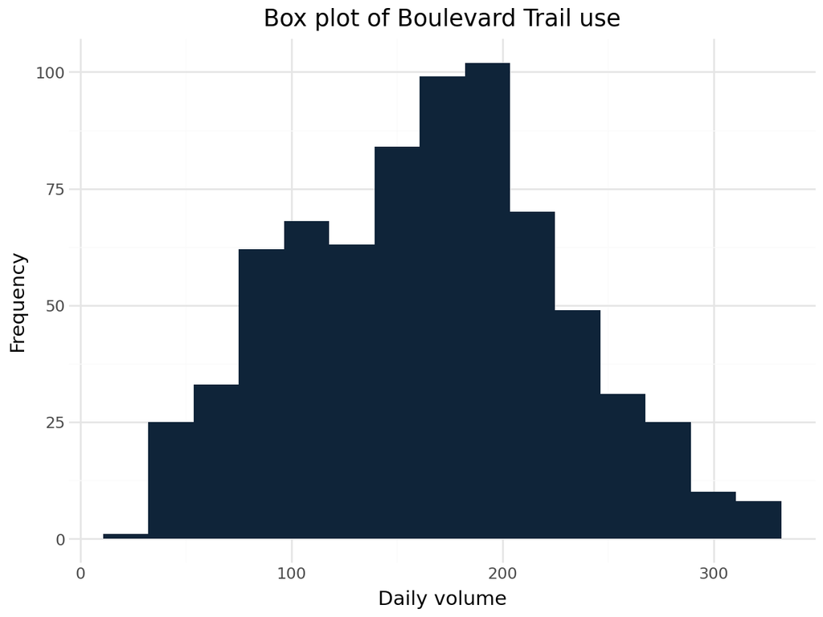

```python
# Histogram
plot = (p9.ggplot(dat, p9.aes(x="CountBL")) +
  p9.geom_histogram(fill="#0F2439") +
  p9.labs(x="Daily volume", y="Frequency",
    title="Box plot of Boulevard Trail use") +
  p9.theme_minimal())
plot.show()
```

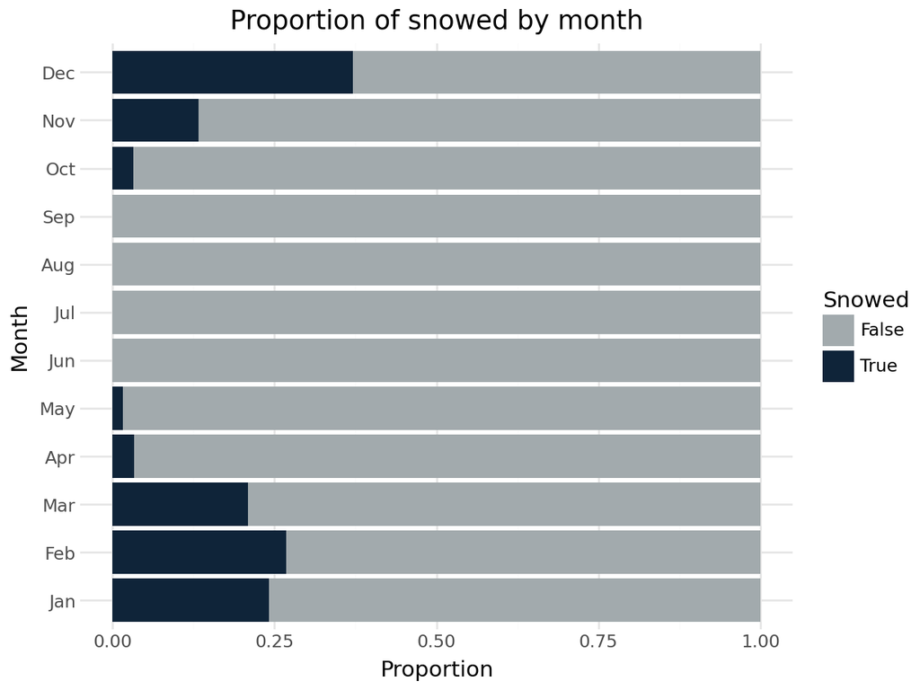

```python
# Stacked bar chart
df1a = pd.DataFrame({'Snowed':[True]*12,
  'Month':tabp2.T.index, 'Proportion':tabp2.T['True']})
df1b = pd.DataFrame({'Snowed':[False]*12,
  'Month':tabp2.T.index, 'Proportion':tabp2.T['False']})
df1 = pd.concat([df1a, df1b])
plot = (p9.ggplot(df1, p9.aes(y="Proportion", x="Month", fill="Snowed")) +
  p9.geom_bar(stat="identity", position="stack") +
  p9.scale_fill_manual(values=["#A2AAAD", "#0F2439"]) +
  p9.labs(y="Proportion", x="Month",
    title="Proportion of snowed by month",
    fill="Snowed") +
  p9.theme_minimal() +
  p9.coord_flip())
plot.show()
```

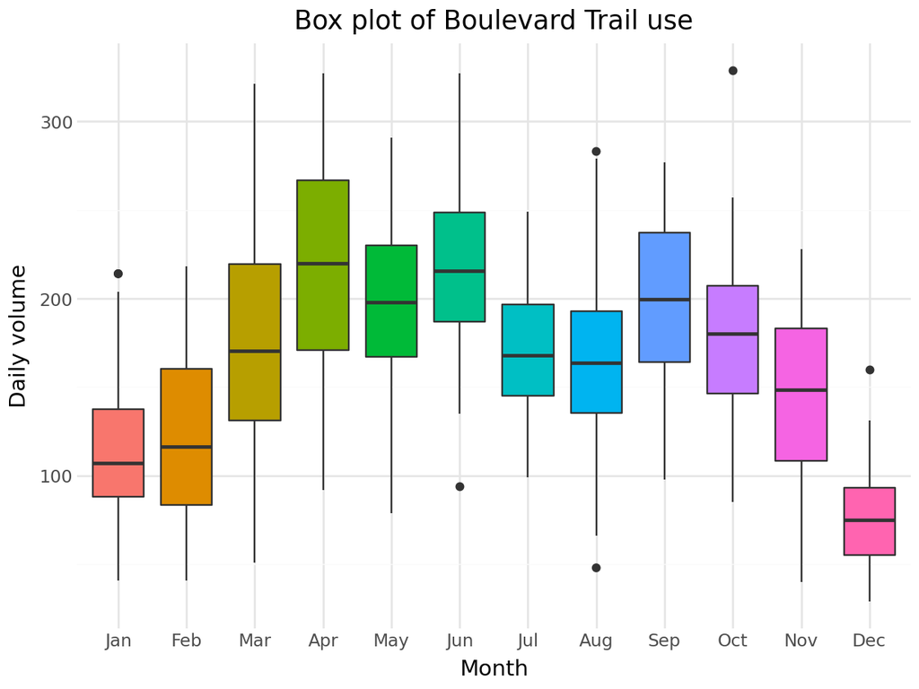

```python
del df1

# Multi-group box plot
plot = (p9.ggplot(dat, p9.aes(x="Month", y="CountBL", fill="Month")) +
  p9.geom_boxplot(show_legend=False) +
  p9.labs(x="Month", y="Daily volume",
    title="Box plot of Boulevard Trail use") +
  p9.theme_minimal())
plot.show()
```

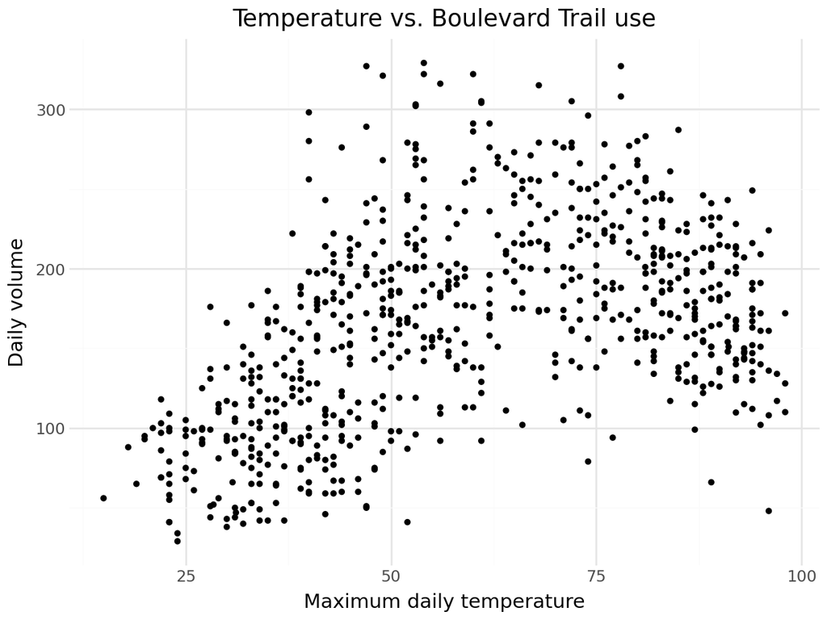

```python
# Scatter plot
plot = (p9.ggplot(dat, p9.aes(x="Temp_Max", y="CountBL")) +
  p9.geom_point(size=1) +
  p9.labs(x="Maximum daily temperature",
       y="Daily volume",
       title="Temperature vs. Boulevard Trail use") +
  p9.theme_minimal())
plot.show()
```

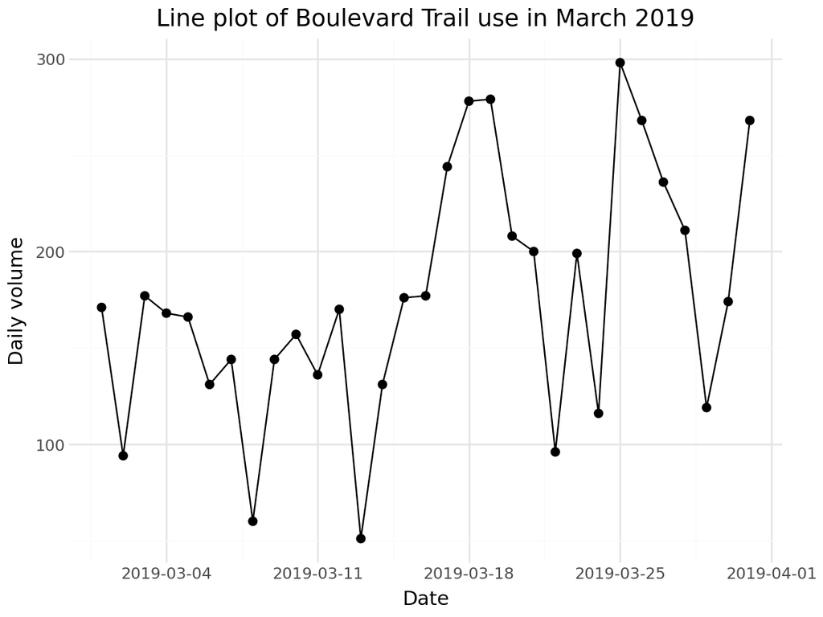

```python
# Line chart
plot = (p9.ggplot(temp1, p9.aes(x="Date", y="CountBL")) +
  p9.geom_line() +
  p9.geom_point(size=2) +
  p9.labs(x="Date", y="Daily volume",
    title = "Line plot of Boulevard Trail use in March 2019") +
  p9.theme_minimal())
plot.show()
```

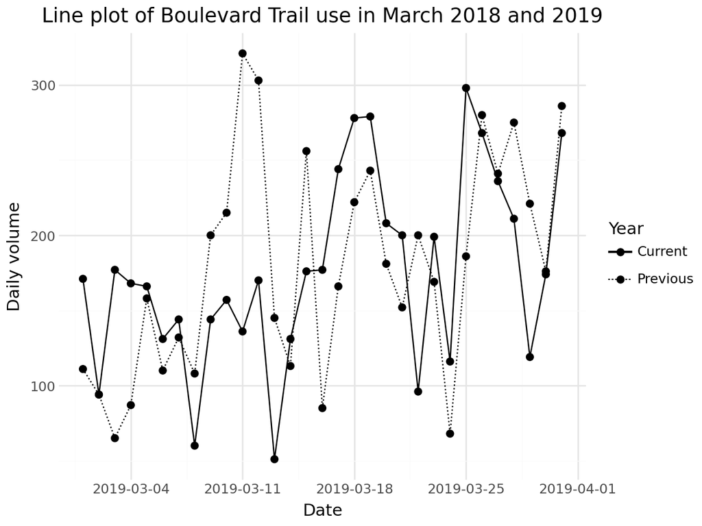

```python
# Line chart
df2 = pd.DataFrame({
    'Date': pd.concat([temp['Date'], temp['Date']], ignore_index=True),
    'Traffic': pd.concat([temp['CountBL'], temp['CountBL_2018']], ignore_index=True),
    'Year': ['Current'] * len(temp) + ['Previous'] * len(temp)
})
plot = (p9.ggplot(df2, p9.aes(x="Date", y="Traffic", color="Year", linetype="Year")) +
  p9.geom_line() +
  p9.geom_point(p9.aes(shape="Year"), size=2) +
  p9.scale_color_manual(values={"Current":"black", "Previous":"black"}) +
  p9.scale_shape_manual(values={"Current":"o", "Previous":"o"}) +
  p9.scale_linetype_manual(values={"Current":"solid", "Previous":"dotted"}) +
  p9.labs(x="Date", y="Daily volume",
    title="Line plot of Boulevard Trail use in March 2018 and 2019") +
  p9.theme_minimal())
plot.show()
```

```python
del df2
```

### Choosing colors

There are lots of resources about using colors in data visualizations in R. For instance: [an R color cheatsheet](https://www.nceas.ucsb.edu/sites/default/files/2020-04/colorPaletteCheatsheet.pdf) and [ColorBrewer](https://colorbrewer2.org/).

I especially like the package `RColorBrewer`, which lets you pick palettes from the [website](https://colorbrewer2.org/).

```r
# Load package
# install.packages("RColorBrewer")
library("RColorBrewer")

# Column chart
brewer.pal(12, "Paired")
```

```
 [1] "#A6CEE3" "#1F78B4" "#B2DF8A" "#33A02C" "#FB9A99" "#E31A1C" "#FDBF6F"
 [8] "#FF7F00" "#CAB2D6" "#6A3D9A" "#FFFF99" "#B15928"
```

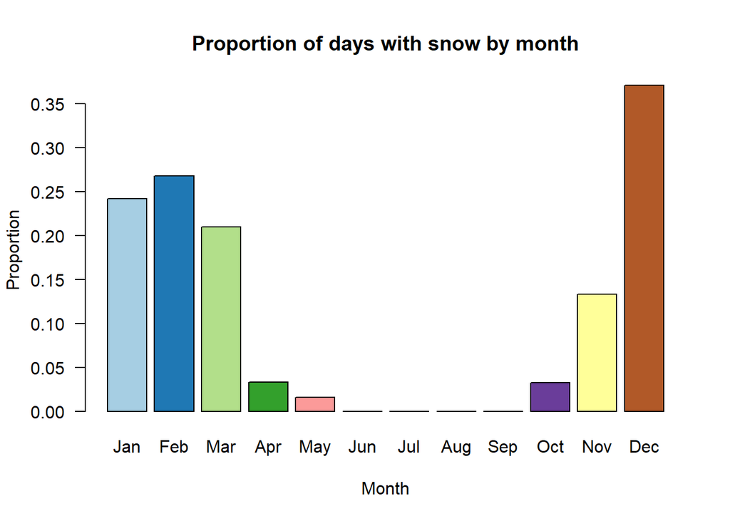

```r
barplot(tabp2["TRUE",], las=1, col=brewer.pal(12, "Paired"),
        ylab="Proportion", xlab="Month",
        main="Proportion of days with snow by month")
```

`seaborn` in Python already comes with many of the ColorBrewer palettes accessible.

```python
# Column chart
tmyptab = tabp2.T
tmyptab["Month"] = tmyptab.index
sns.color_palette("Paired", 12)
```

```
[(0.6509803921568628, 0.807843137254902, 0.8901960784313725), (0.12156862745098039, 0.47058823529411764, 0.7058823529411765), (0.6980392156862745, 0.8745098039215686, 0.5411764705882353), (0.2, 0.6274509803921569, 0.17254901960784313), (0.984313725490196, 0.6039215686274509, 0.6), (0.890196078431372…
```

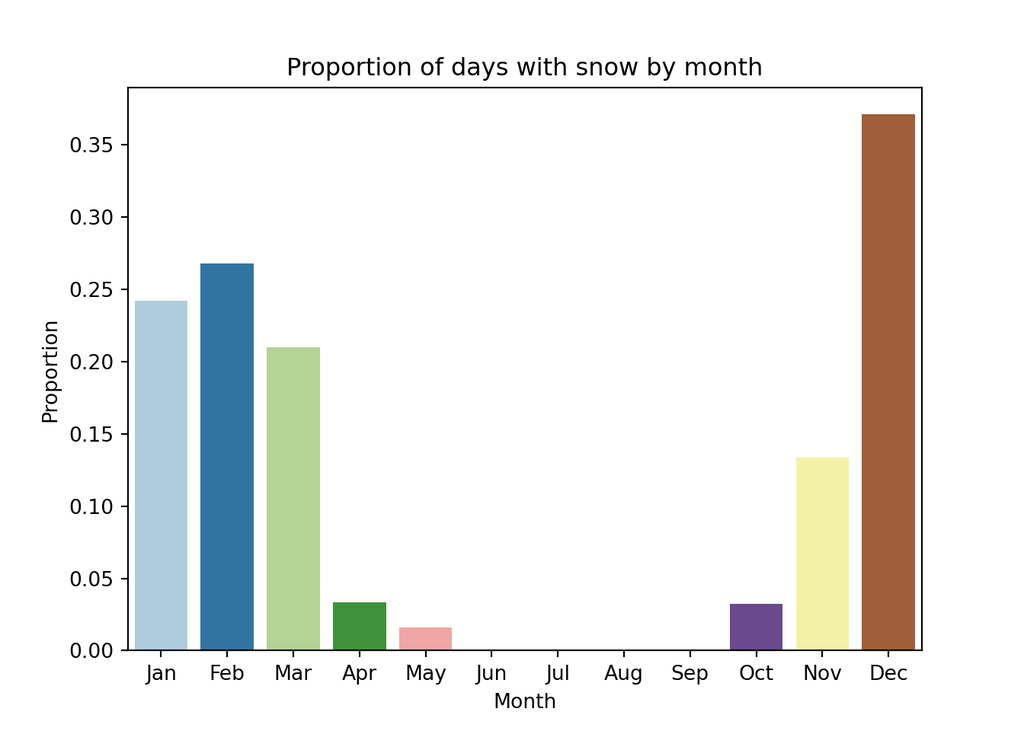

```python
_ = sns.barplot(data=tmyptab, x="Month", y="True",
        palette=sns.color_palette("Paired", 12))
_ = plt.xlabel("Month")
_ = plt.ylabel("Proportion")
_ = plt.title("Proportion of days with snow by month")
plt.show()
```

### Formatting times

When you receive a real-world dataset (including via CSV), any date-time variables will usually NOT be in a nice format. So, you will have to convert them from character to time types.

To do this, we need to understand that R has special classes to represent time. The first, `POSIXct`, stores times as the number of seconds since the start of 1970. The second, `POSIXlt`, stores times as a list of separate elements (seconds, minutes, hours, days, years since 1900, etc.). The third, `Date`, stores dates as the number of days since the start of 1970. ([Why 1970](https://en.wikipedia.org/wiki/Unix_time)?) Usually, we will want to store times in `POSIXct` format and dates in `Date` format. It is relatively easy to convert between different time formats. Although the `POSIX` functions can interpret time formats, to be sure things work you need to specify how the years/months/days/hours/minutes are listed and separated. See `?strptime` for more information.

```r
# See date-time formats
t1 <- Sys.time()
str(t1)
```

```
 POSIXct[1:1], format: "2025-09-05 16:39:56"
```

```r
t1
```

```
[1] "2025-09-05 16:39:56 MDT"
```

```r
t2 <- Sys.Date()
str(t2)
```

```
 Date[1:1], format: "2025-09-05"
```

```r
t2
```

```
[1] "2025-09-05"
```

```r
# Convert character to date-time formats
t3 <- "2023-07-04 21:30:45"
as.Date(t3, format="%Y-%m-%d %H:%M:%S", tz="America/Denver")
```

```
[1] "2023-07-04"
```

```r
as.POSIXct(t3, format="%Y-%m-%d %H:%M:%S", tz="America/Denver")
```

```
[1] "2023-07-04 21:30:45 MDT"
```

```r
# Can accommodate non-standard time formats
t4 <- "Jul 4, 23 9:30pm 45s"
as.POSIXct(t4, format="%b %e, %y %I:%M%p %Ss", tz="America/Denver")
```

```
[1] "2023-07-04 21:30:45 MDT"
```

Here are some other resources for dealing with time in R:

- [Dates and Times in R](https://www.stat.berkeley.edu/~s133/dates.html) from Phil Spector (University of California Berkeley).
- [Time Data Types](http://www.cyclismo.org/tutorial/R/time.html) from Kelly Black (University of Georgia).
- [Dates and times](https://r4ds.hadley.nz/datetimes.html) from Hadley Wickham et al.

Python has a native `datetime` object and a `Timestamp` object from `pandas`. It is fairly easy to convert time stored as a string into a time format, using `to_datetime()`.

```python
# See date-time formats
t1 = pd.Timestamp.now()
type(t1)
t1
t2 = pd.Timestamp.today().normalize()
type(t2)
t2

# Convert character to date-time formats
t3 = "2023-07-04 21:30:45"
pd.to_datetime(t3, format="%Y-%m-%d %H:%M:%S").date()
pd.to_datetime(t3, format="%Y-%m-%d %H:%M:%S").tz_localize("America/Denver")

# Can accommodate non-standard time formats
t4 = "Jul 4, 23 9:30pm 45s"
pd.to_datetime(t4, format="%b %d, %y %I:%M%p %Ss").tz_localize("America/Denver")
```

Here are some other resources for dealing with dates and times in Python:

- [datetime – Basic date and time types](https://docs.python.org/3/library/datetime.html) from Python.
- [Python Datetime](https://www.w3schools.com/python/python_datetime.asp) from W3Schools.
- [Working with Time Series](https://jakevdp.github.io/PythonDataScienceHandbook/03.11-working-with-time-series.html) from Jake VanderPlas.

## Review

- Can you merge or join two datasets together based on a common key/column?
- Can you process dates and extract information?
- Can you determine which charts are appropriate for visualizing the composition of a single categorical variable?
- Can you determine which charts are appropriate for visualizing the distribution of a single continuous variable?
- Can you determine which charts are appropriate for visually comparing two (or more) groups or variables?
- Can you determine which charts are appropriate for visualizing relationships between two variables?
- Can you create a basic version of each of the following charts: bar chart, stacked bar chart, box plot, histogram, scatter diagram?

**END**